# Hướng dẫn vẽ đồ thị nhiều biến

**Biên soạn**

ThS. Nguyễn Tấn Đức | [www.tuhocr.com](https://www.tuhocr.com/)

**Cập nhật**

2024 June 06

[Register](https://www.tuhocr.com/register) [Source](https://applyr.netlify.app/codebase/quarto-multivariate-plot/quarto-multivariate-plot.txt) [Web](https://applyr.netlify.app/codebase/quarto-multivariate-plot/quarto-multivariate-plot.html)

# 1 Tình huống thường gặp

Bạn có dataset gồm nhiều cột dữ liệu (biến liên tục, biến định lượng, số đếm) như vậy để thể hiện nhiều nhất số lượng các biến này lên đồ thị 2D thì ta sẽ thực hiện như thế nào. Các dạng đồ thị có nhiều biến (multivariate plot) giúp lồng ghép nhiều thông tin khác nhau vào trong cùng một đồ thị, tuy nhiên bạn cũng có thể tách ra thành các đồ thị con để giúp người đọc dễ tiếp nhận được thông điệp từ đồ thị. Trong ví dụ này mình sử dụng dataset `state.x77` về thông tin 50 bang nước Mỹ ở thập niên 1970.

[**Video hướng dẫn chi tiết và các tài liệu liên quan được upload ở tài khoản học viên.**](https://www.tuhocr.com/r-courses/data-visualization-in-r)

# 2 Chuẩn bị dataset

```r
state.x77 -> df

df_1 <- as.data.frame(df)

df_1$State <- row.names(df_1)

row.names(df_1) <- NULL

df_1 <- df_1[, c(9, 1:4, 6, 8)]

names(df_1)[5] <- "Life_Exp"

names(df_1)[6] <- "HS_Grad"

df_1 # mặc định thì dataset này xếp thứ tự bang nước Mỹ theo alphabet
```

```
            State Population Income Illiteracy Life_Exp HS_Grad   Area
1         Alabama       3615   3624        2.1    69.05    41.3  50708
2          Alaska        365   6315        1.5    69.31    66.7 566432
3         Arizona       2212   4530        1.8    70.55    58.1 113417
4        Arkansas       2110   3378        1.9    70.66    39.9  51945
5      California      21198   5114        1.1    71.71    62.6 156361
6        Colorado       2541   4884        0.7    72.06    63.9 103766
7     Connecticut       3100   5348        1.1    72.48    56.0   4862
8        Delaware        579   4809        0.9    70.06    54.6   1982
9         Florida       8277   4815        1.3    70.66    52.6  54090
10        Georgia       4931   4091        2.0    68.54    40.6  58073
11         Hawaii        868   4963        1.9    73.60    61.9   6425
12          Idaho        813   4119        0.6    71.87    59.5  82677
13       Illinois      11197   5107        0.9    70.14    52.6  55748
14        Indiana       5313   4458        0.7    70.88    52.9  36097
```

[output cut: 36 more lines]

**Thông tin các cột như sau:**

- `Population` population estimate as of July 1, 1975 (đơn vị ngàn dân)
- `Income` per capita income (1974) (đơn vị USD)
- `Illiteracy` tỷ lệ mù chữ (1970, percent of population)
- `Life_Exp` tuổi thọ trung bình (life expectancy in years 1969–71)
- `HS Grad` tỷ lệ tốt nghiệp trung học phổ thông (percent high-school graduates in 1970)
- `Area` diện tích (land area in square miles)

# 3 Vẽ đồ thị scatter plot 2 biến

Ta có thể sử dụng cột `Income` và `Life_Exp` để biểu diễn đặc trưng giữa các bang trong nước Mỹ với hai biến này.

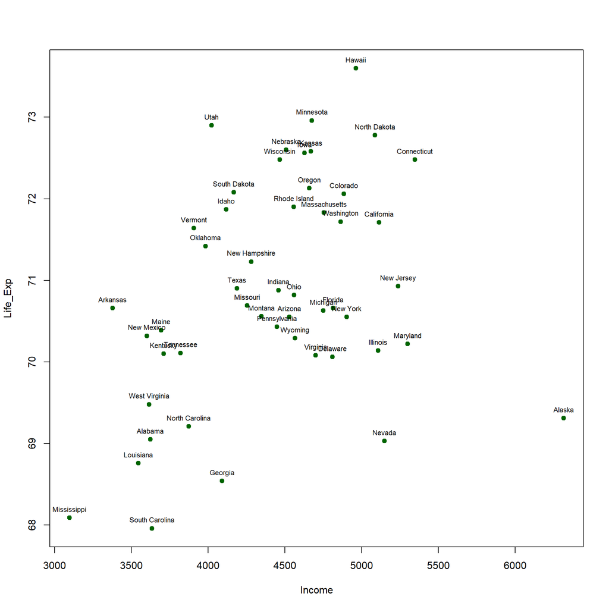

```r
plot(formula = Life_Exp ~ Income,
     data = df_1,
     pch = 19,
     col = "darkgreen")

text(x = df_1$Income,
     y = df_1$Life_Exp,
     cex = 0.7,
     labels = df_1$State,
     pos = 3)
```

# 4 Thêm thông tin về dân số

**Áp dụng lệnh `cut()` để tạo group cho biến dân số, đây là kỹ thuật chuyển biến định lượng sang biến phân loại. Sử dụng tham số `col` màu sắc để biểu diễn biến dân số.**

```r
df_1$Population_group <- cut(x = df_1$Population,
                       breaks = c(0, 500, 1000, 5000, 10000, 30000),
                       labels = c("≤ 500",
                                  "500 < population ≤ 1000",
                                  "1000 < population ≤ 5000",
                                  "5000 < population ≤ 10000",
                                  "> 10000"))

df_1 |> dplyr::arrange(desc(Population_group), desc(Income)) -> df_2

df_2
```

```
            State Population Income Illiteracy Life_Exp HS_Grad   Area          Population_group
1      California      21198   5114        1.1    71.71    62.6 156361                   > 10000
2        Illinois      11197   5107        0.9    70.14    52.6  55748                   > 10000
3        New York      18076   4903        1.4    70.55    52.7  47831                   > 10000
4            Ohio      10735   4561        0.8    70.82    53.2  40975                   > 10000
5    Pennsylvania      11860   4449        1.0    70.43    50.2  44966                   > 10000
6           Texas      12237   4188        2.2    70.90    47.4 262134                   > 10000
7      New Jersey       7333   5237        1.1    70.93    52.5   7521 5000 < population ≤ 10000
8         Florida       8277   4815        1.3    70.66    52.6  54090 5000 < population ≤ 10000
9   Massachusetts       5814   4755        1.1    71.83    58.5   7826 5000 < population ≤ 10000
10       Michigan       9111   4751        0.9    70.63    52.8  56817 5000 < population ≤ 10000
11        Indiana       5313   4458        0.7    70.88    52.9  36097 5000 < population ≤ 10000
12 North Carolina       5441   3875        1.8    69.21    38.5  48798 5000 < population ≤ 10000
13    Connecticut       3100   5348        1.1    72.48    56.0   4862  1000 < population ≤ 5000
14       Maryland       4122   5299        0.9    70.22    52.3   9891  1000 < population ≤ 5000
```

[output cut: 36 more lines]

**Áp dụng cách subset vector theo factor để tạo ra vector chứa màu sắc tương ứng từng mức trong biến `Population_group`.**

```r
levels(df_2$Population_group)
```

```
[1] "≤ 500"                     "500 < population ≤ 1000"   "1000 < population ≤ 5000"  "5000 < population ≤ 10000" "> 10000"
```

```r
color_area_group <- c("#ff99e6", # level thấp
                      "#C17EFB",
                      "#7900cc",
                      "#cc0000",
                      "#ff0000") # level cao

color_area_group[df_2$Population_group]
```

```
 [1] "#ff0000" "#ff0000" "#ff0000" "#ff0000" "#ff0000" "#ff0000" "#cc0000" "#cc0000" "#cc0000" "#cc0000" "#cc0000" "#cc0000" "#7900cc" "#7900cc" "#7900cc" "#7900cc" "#7900cc" "#7900cc" "#7900cc" "#7900cc" "#7900cc" "#7900cc" "#7900cc" "#7900cc" "#7900cc" "#7900cc" "#7900cc" "#7900cc" "#7900cc" "#790…
```

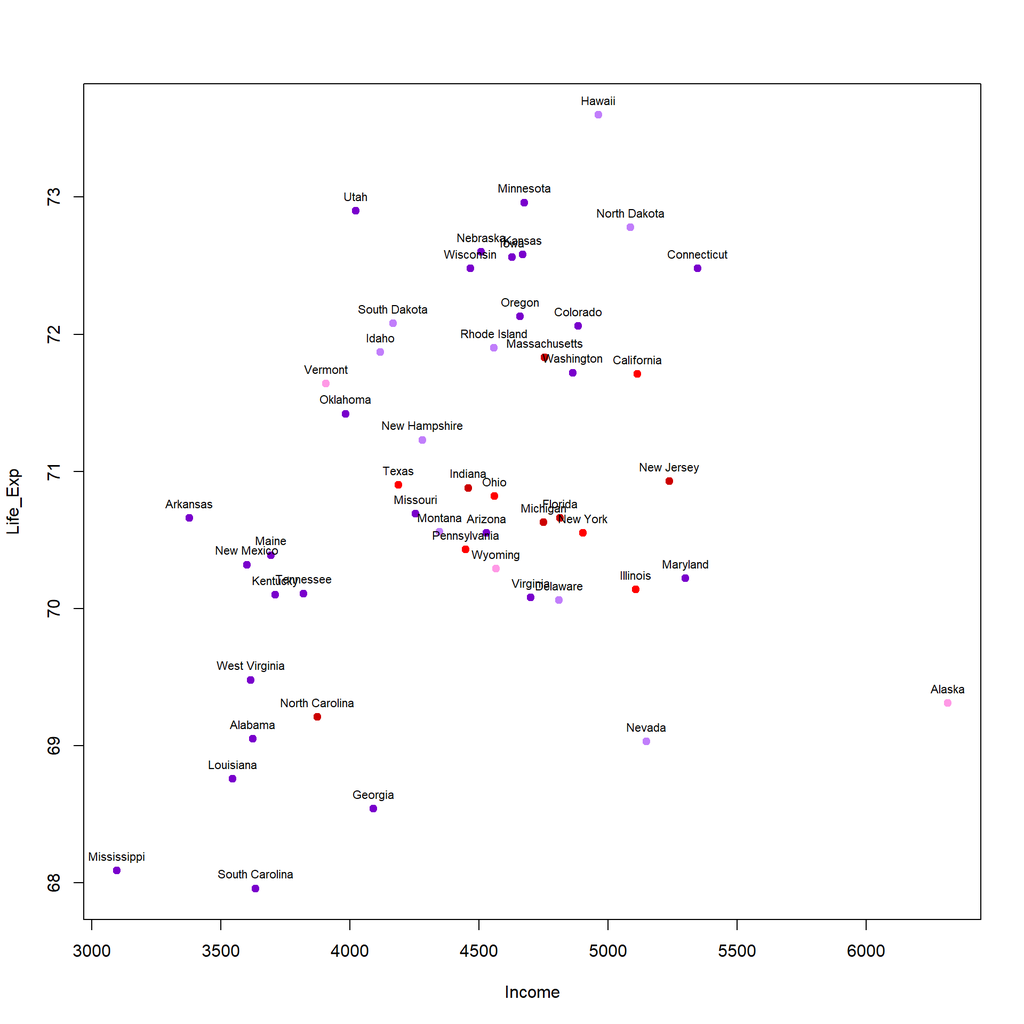

```r
plot(formula = Life_Exp ~ Income,
     data = df_2,
     pch = 19,
     col = color_area_group[df_2$Population_group])

text(x = df_2$Income,
     y = df_2$Life_Exp,
     cex = 0.7,
     labels = df_2$State,
     pos = 3)
```

# 5 Thêm thông tin về diện tích

Cách 1: Ta sẽ biểu diễn diện tích của các bang theo độ lớn của point character, sử dụng tham số `cex`, để làm được như vậy cần quy đổi về tỷ lệ giữa các bang và chuyển thành các mức `cex` phù hợp (đây là cách vẽ bubble chart).

Cách 2: Ta cắt dữ liệu ra tương tự như biến dân số, sau đó gán vào tỷ lệ `cex` phù hợp. Ở đây ta chọn cách 2 để thực hiện.

```r
### cách 1
# prop.table(df_2$Area) -> df_2$cex_area
#
# library(car)
# df_2$cex_area_ok <- car::recode(df_2$cex_area,
#                                "0.0001:0.0005 = 1;
#                                 0.0005:0.01  = 1.5;
#                                 0.01:0.05 = 2;
#                                 0.05:0.1 = 2.5;
#                                 else = 3")

### cách 2
df_2$Area_group <- cut(x = df_2$Area,
                       breaks = c(0, 5000, 10000, 30000,
                                  100000, 300000, 600000),
                       labels = c("≤ 5000",
                                  "5000 < area ≤ 10000",
                                  "10000 < area ≤ 30000",
                                  "30000 < area ≤ 100000",
                                  "100000 < area ≤ 300000",
                                  "> 300000"))

df_2$cex_area_ok <- car::recode(df_2$Area_group,
                               " '≤ 5000' = 1;
                                '5000 < area ≤ 10000'  = 1.25;
                                '10000 < area ≤ 30000' = 1.5;
                                '30000 < area ≤ 100000' = 2;
                                '100000 < area ≤ 300000' = 2.75;
                                else = 3")

df_2$cex_area_ok <- as.character(df_2$cex_area_ok)
df_2$cex_area_ok <- as.numeric(df_2$cex_area_ok)

df_2
```

```
            State Population Income Illiteracy Life_Exp HS_Grad   Area          Population_group             Area_group cex_area_ok
1      California      21198   5114        1.1    71.71    62.6 156361                   > 10000 100000 < area ≤ 300000        2.75
2        Illinois      11197   5107        0.9    70.14    52.6  55748                   > 10000  30000 < area ≤ 100000        2.00
3        New York      18076   4903        1.4    70.55    52.7  47831                   > 10000  30000 < area ≤ 100000        2.00
4            Ohio      10735   4561        0.8    70.82    53.2  40975                   > 10000  30000 < area ≤ 100000        2.00
5    Pennsylvania      11860   4449        1.0    70.43    50.2  44966                   > 10000  30000 < area ≤ 100000        2.00
6           Texas      12237   4188        2.2    70.90    47.4 262134                   > 10000 100000 < area ≤ 300000        2.75
7      New Jersey       7333   5237        1.1    70.93    52.5   7521 5000 < population ≤ 10000    5000 < area ≤ 10000        1.25
8         Florida       8277   4815        1.3    70.66    52.6  54090 5000 < population ≤ 10000  30000 < area ≤ 100000        2.00
9   Massachusetts       5814   4755        1.1    71.83    58.5   7826 5000 < population ≤ 10000    5000 < area ≤ 10000        1.25
10       Michigan       9111   4751        0.9    70.63    52.8  56817 5000 < population ≤ 10000  30000 < area ≤ 100000        2.00
11        Indiana       5313   4458        0.7    70.88    52.9  36097 5000 < population ≤ 10000  30000 < area ≤ 100000        2.00
12 North Carolina       5441   3875        1.8    69.21    38.5  48798 5000 < population ≤ 10000  30000 < area ≤ 100000        2.00
13    Connecticut       3100   5348        1.1    72.48    56.0   4862  1000 < population ≤ 5000                 ≤ 5000        1.00
14       Maryland       4122   5299        0.9    70.22    52.3   9891  1000 < population ≤ 5000    5000 < area ≤ 10000        1.25
```

[output cut: 36 more lines]

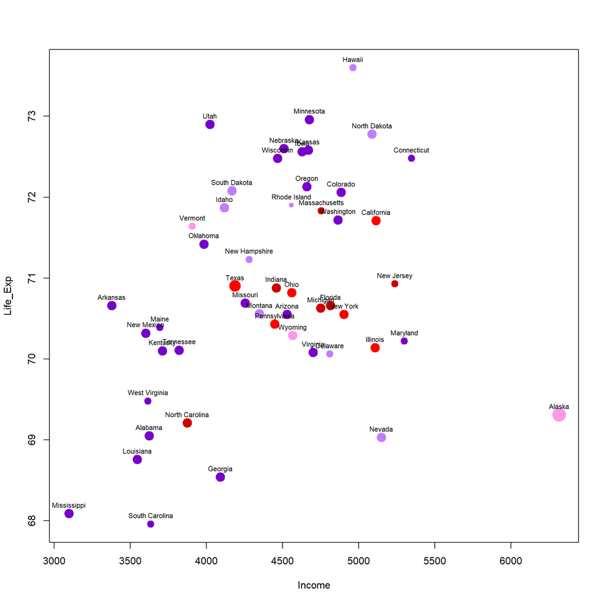

```r
plot(formula = Life_Exp ~ Income,
     data = df_2,
     pch = 19,
     cex = df_2$cex_area_ok,
     col = color_area_group[df_2$Population_group])

text(x = df_2$Income,
     y = df_2$Life_Exp,
     cex = 0.7,
     labels = df_2$State,
     pos = 3)
```

# 6 Thêm điều kiện về tuổi thọ

**Ta sử dụng hai tính chất của point character (từ 21 đến 25) là có thể tô màu viền `col` và màu nền `bg` để đưa thêm điều kiện về tuổi thọ trung bình vào đồ thị, để dễ quan sát ta sẽ chỉnh lại độ trong suốt về màu sắc giữa các điểm dữ liệu.**

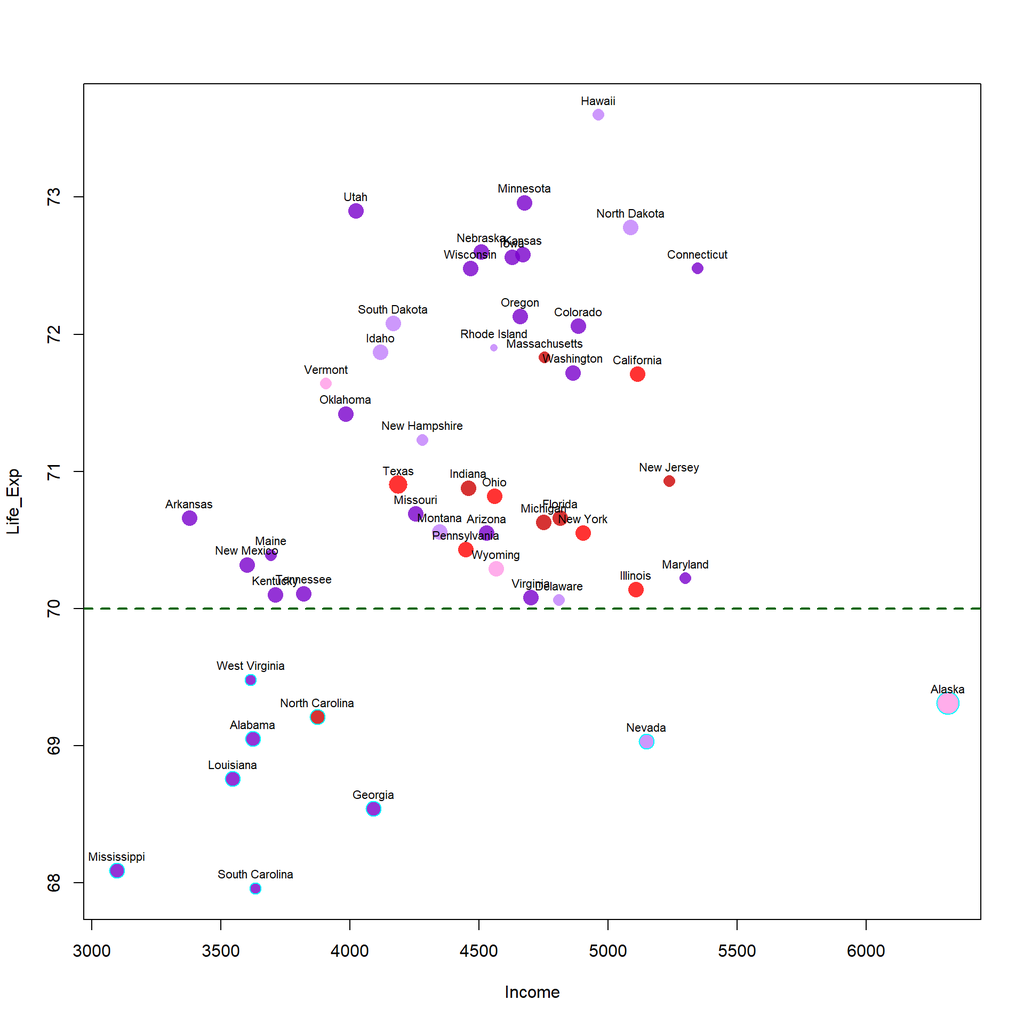

```r
plot(formula = Life_Exp ~ Income,
     data = df_2,
     pch = 21,
     cex = df_2$cex_area_ok,
     bg = adjustcolor(color_area_group[df_2$Population_group], alpha.f = 0.8),
     lwd = 1,
     col = ifelse(df_2$Life_Exp <= 70,
                  yes = adjustcolor("cyan", alpha.f = 1),
                  no = adjustcolor("transparent", alpha.f = 1)))

text(x = df_2$Income,
     y = df_2$Life_Exp,
     cex = 0.7,
     labels = df_2$State,
     pos = 3)

abline(h = 70, lty = 2, lwd = 2, col = "darkgreen")
```

# 7 Gộp hai biến cũ để tạo thành biến mới

**Tiếp đó ta có biến `HS_Grad` đại diện cho tỷ lệ tốt nghiệp trung học phổ thông (tú tài) trên tổng số dân, nếu biểu diễn biến này thì cũng được, tuy nhiên để minh họa cách tận dụng dữ liệu thì mình sẽ tạo ra biến mới, gọi là `Edu_index` đại diện cho tỷ lệ tốt nghiệp trung học phổ thông tính trên tổng số dân biết chữ, để đánh giá mức độ học vấn giữa các bang. Như vậy sẽ gộp được hai biến gốc là `Illiteracy` và `HS_Grad` thành biến mới `Edu_index` giúp tăng thêm thông tin cho đồ thị.**

[**View dataset final**](https://applyr.netlify.app/codebase/quarto-multivariate-plot/output.html)

```r
df_2$Literacy <- 100 - df_2$Illiteracy

df_2$Edu_index <- df_2$HS_Grad / df_2$Literacy

## tạo group cho biến `Edu_index`

df_2$Edu_index_group <- car::recode(df_2$Edu_index,
                                    "0:0.4 = 'low';
                                     0.4:0.6  = 'medium';
                                     else = 'high'")

df_2$Edu_index_group <- factor(df_2$Edu_index_group,
                               levels = c("low", "medium", "high"),
                               ordered = TRUE)

library(kableExtra)
df_2 %>% kbl(format = "html") %>%
  kable_styling(bootstrap_options = c("striped",
                                      "hover",
                                      "condensed",
                                      "bordered",
                                      "responsive")) %>%
  row_spec(0, bold = TRUE, align = "c", color = "white", background = "#1d6c00") %>%
  kable_classic(full_width = TRUE, html_font = "arial") -> output

save_kable(output, file = "output.html")
```

**Vẽ đồ thị với tham số `pch` đại diện cho chỉ số `Edu_index` ở từng bang.**

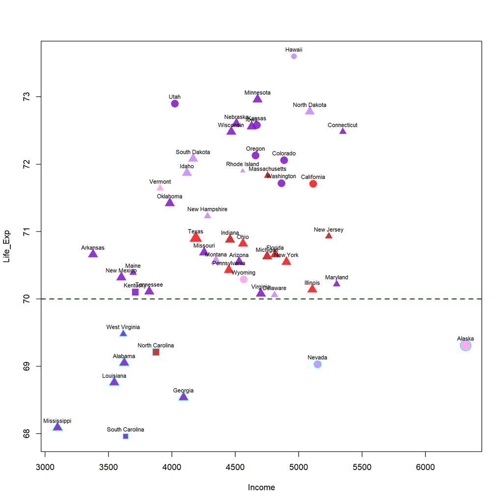

```r
plot(formula = Life_Exp ~ Income,
     data = df_2,
     pch = c(22, 24, 21)[df_2$Edu_index_group],
     cex = df_2$cex_area_ok,
     bg = adjustcolor(color_area_group[df_2$Population_group], alpha.f = 0.8),
     lwd = 1,
     col = ifelse(df_2$Life_Exp <= 70,
                  yes = adjustcolor("cyan", alpha.f = 1),
                  no = adjustcolor("transparent", alpha.f = 1)))

text(x = df_2$Income,
     y = df_2$Life_Exp,
     cex = 0.7,
     labels = df_2$State,
     pos = 3)

abline(h = 70, lty = 2, lwd = 2, col = "darkgreen")
```

# 8 Chỉnh lại text không bị overlap

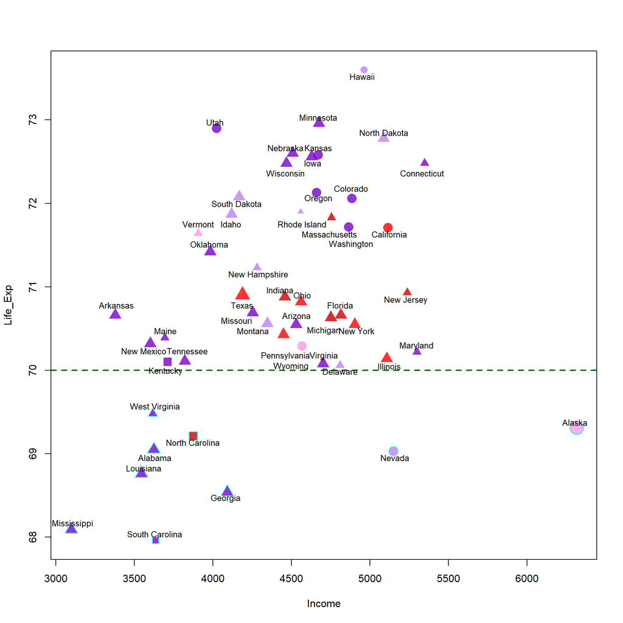

```r
plot(formula = Life_Exp ~ Income,
     data = df_2,
     pch = c(22, 24, 21)[df_2$Edu_index_group],
     cex = df_2$cex_area_ok,
     bg = adjustcolor(color_area_group[df_2$Population_group], alpha.f = 0.8),
     lwd = 1,
     col = ifelse(df_2$Life_Exp <= 70,
                  yes = adjustcolor("cyan", alpha.f = 1),
                  no = adjustcolor("transparent", alpha.f = 1)))

# text(x = df_2$Income,
#      y = df_2$Life_Exp,
#      cex = 0.7,
#      labels = df_2$State,
#      pos = 3)

abline(h = 70, lty = 2, lwd = 2, col = "darkgreen")

library(basicPlotteR)
basicPlotteR::addTextLabels(xCoords = df_2$Income,
                            yCoords = df_2$Life_Exp,
                            labels = df_2$State,
                            keepLabelsInside = TRUE,
                            # border = "black",
                            # col.background = "lightyellow",
                            avoidPoints = TRUE,
                            col.label = "black",
                            col.line = NA,
                            cex.label = 0.8,
                            cex.pt = 0.9)
```

# 9 Thêm đường đồng mức thể hiện mật độ điểm dữ liệu

Khi ta có đồ thị scatter plot với mật độ điểm tập trung dày đặc, để thể hiện phân bố 2D cho hai biến `x` và `y` tương ứng ta sẽ vẽ đường đồng mức (thực tế là biến `z` đại diện cho mật độ điểm trên một đơn vị diện tích ở đồ thị scatter plot ban đầu). Thông tin chi tiết các bạn xem thêm ở đây nhé.[^1]

> `dataEllipse` superimposes the normal-probability contours over a scatterplot of the data

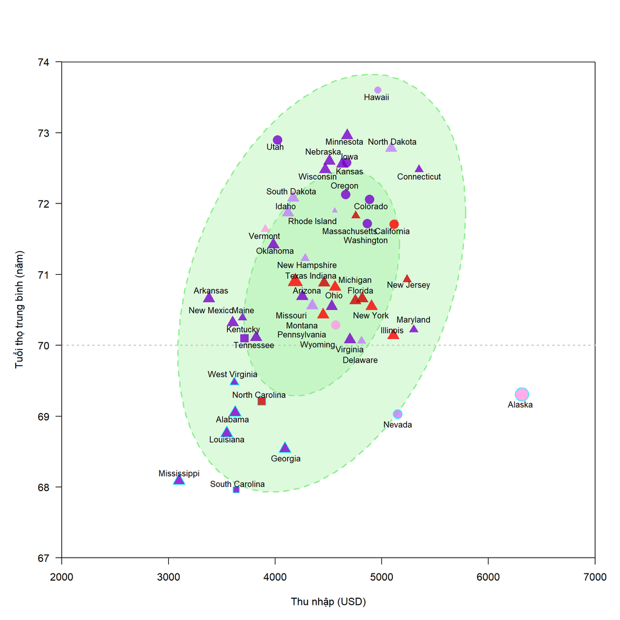

```r
par(mar = c(5, 5, 5, 2))

plot(formula = Life_Exp ~ Income,
     data = df_2,
     type = "n",
     pch = c(22, 24, 21)[df_2$Edu_index_group],
     cex = df_2$cex_area_ok,
     bg = adjustcolor(color_area_group[df_2$Population_group], alpha.f = 0.8),
     lwd = 1,
     col = ifelse(df_2$Life_Exp <= 70,
                  yes = adjustcolor("cyan", alpha.f = 1),
                  no = adjustcolor("transparent", alpha.f = 1)),
     xlim = c(2000, 7000),
     ylim = c(67, 74),
     xaxs = "i",
     yaxs = "i",
     xlab = "Thu nhập (USD)",
     ylab = "Tuổi thọ trung bình (năm)",
     las = 1)

car::dataEllipse(x = df_2$Income,
                 y = df_2$Life_Exp,
                 plot.points = FALSE,
                 col = "lightgreen",
                 center.pch = FALSE,
                 fill = TRUE,
                 levels = c(0.5, 0.9),
                 fill.alpha = 0.3,
                 grid = TRUE,
                 lty = 2)

abline(h = 70, lty = 3, lwd = 2, col = adjustcolor("gray", alpha.f = 0.8))

points(formula = Life_Exp ~ Income,
     data = df_2,
     type = "p",
     pch = c(22, 24, 21)[df_2$Edu_index_group],
     cex = df_2$cex_area_ok,
     bg = adjustcolor(color_area_group[df_2$Population_group], alpha.f = 0.8),
     lwd = 1,
     col = ifelse(df_2$Life_Exp <= 70,
                  yes = adjustcolor("cyan", alpha.f = 1),
                  no = adjustcolor("transparent", alpha.f = 1)),
     xlim = c(2000, 7000),
     ylim = c(67, 74),
     xaxs = "i",
     yaxs = "i",
     las = 1)

library(basicPlotteR)
basicPlotteR::addTextLabels(xCoords = df_2$Income,
                            yCoords = df_2$Life_Exp,
                            labels = df_2$State,
                            keepLabelsInside = TRUE,
                            # border = "black",
                            # col.background = "lightyellow",
                            avoidPoints = TRUE,
                            col.label = "black",
                            col.line = NA,
                            cex.label = 0.8,
                            cex.pt = 0.9)
```

# 10 Thêm chú thích và hoàn thiện đồ thị

[figure not shown]

```r
par(mar = c(5, 5, 5, 2))
par(font.lab = 2)
par(font.axis = 2)

plot(formula = Life_Exp ~ Income,
     data = df_2,
     type = "n",
     pch = c(22, 24, 21)[df_2$Edu_index_group],
     cex = df_2$cex_area_ok,
     bg = adjustcolor(color_area_group[df_2$Population_group], alpha.f = 0.8),
     lwd = 1,
     col = ifelse(df_2$Life_Exp <= 70,
                  yes = adjustcolor("cyan", alpha.f = 1),
                  no = adjustcolor("transparent", alpha.f = 1)),
     xlim = c(2000, 7000),
     ylim = c(67, 74),
     xaxs = "i",
     yaxs = "i",
     xlab = "Thu nhập bình quân đầu người (USD)",
     ylab = "Tuổi thọ trung bình (năm)",
     las = 1)

car::dataEllipse(x = df_2$Income,
                 y = df_2$Life_Exp,
                 plot.points = FALSE,
                 col = "lightgreen",
                 center.pch = FALSE,
                 fill = TRUE,
                 levels = c(0.5, 0.9),
                 fill.alpha = 0.3,
                 grid = TRUE,
                 lty = 2)

abline(h = 70, lty = 3, lwd = 2, col = adjustcolor("gray", alpha.f = 0.8))

points(formula = Life_Exp ~ Income,
     data = df_2,
     type = "p",
     pch = c(22, 24, 21)[df_2$Edu_index_group],
     cex = df_2$cex_area_ok,
     bg = adjustcolor(color_area_group[df_2$Population_group], alpha.f = 0.8),
     lwd = 1,
     col = ifelse(df_2$Life_Exp <= 70,
                  yes = adjustcolor("cyan", alpha.f = 1),
                  no = adjustcolor("transparent", alpha.f = 1)),
     xlim = c(2000, 7000),
     ylim = c(67, 74),
     xaxs = "i",
     yaxs = "i",
     las = 1)

library(basicPlotteR)
basicPlotteR::addTextLabels(xCoords = df_2$Income,
                            yCoords = df_2$Life_Exp,
                            labels = df_2$State,
                            keepLabelsInside = TRUE,
                            # border = "black",
                            # col.background = "lightyellow",
                            avoidPoints = TRUE,
                            col.label = "black",
                            col.line = NA,
                            cex.label = 0.8,
                            cex.pt = 0.9)

### legend dân số

legend(x = "topright",
       y = NULL,
       title = "Dân số (nghìn người)",
       title.font = 2,
       legend = levels(df_2$Population_group),
       col = color_area_group,
       pt.cex = 1.5,
       y.intersp = 1.25,
       x.intersp = 1.25,
       inset = 0.01,
       bty = "n",
       pch = 19)

### legend diện tích

leg <- legend(x = "bottomright",
       y = NULL,
       title = "Diện tích (square mile)",
       legend = c("≤ 5000",
                  "5000 < area ≤ 10000",
                  "10000 < area ≤ 30000",
                  "30000 < area ≤ 100000",
                  "100000 < area ≤ 300000",
                  "> 300000"),
       col = "black",
       pch = 1,
       y.intersp = c(1, 1.25, 1.25, 1.25, 1.5, 1.5),
       pt.cex = c(1, 1.25, 1.5, 2, 2.75, 3),
       bty = "n",
       plot = FALSE)

legend(x = leg$rect$left - 400,
       y = leg$rect$top,
       title = "",
       legend = c("",
                  "",
                  "",
                  "",
                  "",
                  ""),
       col = "black",
       pch = 0,
       y.intersp = c(1, 1.25, 1.25, 1.25, 1.5, 1.5),
       pt.cex = c(1, 1.25, 1.5, 2, 2.75, 3),
       bty = "n")

legend(x = leg$rect$left - 200,
       y = leg$rect$top,
       title = "",
       legend = c("",
                  "",
                  "",
                  "",
                  "",
                  ""),
       col = "black",
       pch = 2,
       y.intersp = c(1, 1.25, 1.25, 1.25, 1.5, 1.5),
       pt.cex = c(1, 1.25, 1.5, 2, 2.75, 3),
       bty = "n")

legend(x = "bottomright",
       y = NULL,
       title.font = 2,
       title = "Diện tích (square mile)",
       legend = c("≤ 5000",
                  "5000 < area ≤ 10000",
                  "10000 < area ≤ 30000",
                  "30000 < area ≤ 100000",
                  "100000 < area ≤ 300000",
                  "> 300000"),
       col = "black",
       pch = 1,
       x.intersp = 1.25,
       y.intersp = c(1, 1.25, 1.25, 1.25, 1.5, 1.5),
       pt.cex = c(1, 1.25, 1.5, 2, 2.75, 3),
       plot = TRUE,
       bty = "n")

### legend edu index

legend(x = "topleft",
       y = NULL,
       title = "Tỷ lệ tốt nghiệp tú tài (%)\ntính trên tổng số người biết chữ",
       title.font = 2,
       legend = c("≤ 40 ~ Low",
                  "40–60 ~ Medium",
                  "> 60 ~ High"),
       col = "black",
       pt.bg = "gray",
       pt.cex = 1.5,
       y.intersp = 1.25,
       x.intersp = 1.25,
       inset = 0.01,
       bty = "n",
       pch = c(22, 24, 21))

### legend other

legend(x = "bottomleft",
       y = NULL,
       title = "Ghi chú",
       title.font = 2,
       legend = c("Point có viền (Life_Exp ≤ 70)",
                  "Point không viền (Life_Exp > 70)"),
       col = c("cyan", "purple"),
       lwd = 2,
       lty = 0,
       pt.bg = "purple",
       merge = FALSE,
       pt.cex = 1.5,
       horiz = FALSE,
       bty = "n",
       pch = c(21, 19))

title(main = "Thông tin về các tiểu bang Hoa Kỳ (thập niên 1970) | Hướng dẫn vẽ đồ thị nhiều biến",
      cex.main = 1.5,
      col.main = "darkblue")
mtext(text = "Source: Dataset state.x77\nThis plot is only for training R",
      side = 1,
      col = "blue",
      font = 3,
      line = 3.5,
      adj = 0,
      xpd = NA)

box()

library(png)
library(grid)
logor <- readPNG("logor.png")

scale_logo <- 0.08

grid.raster(logor,
            x = 0.9,
            y = 0.70,
            width = scale_logo)
```

# 11 Tài liệu tham khảo

1. https://www.visiondummy.com/2014/04/draw-error-ellipse-representing-covariance-matrix/

## Footnotes

[^1]: https://statisticsbyjim.com/graphs/contour-plots/